# Data Workflows II - Tidyverse

[figure not shown]

$+$

[figure not shown]

$=$

[figure not shown]

## Impetus

This homework focuses on how we can use `tidyverse` routines to become more effective in our pre-treatment of data. As a reminder, the operative *verbs* we use in data preparation include:

- *Select*
- *Filter*
- *Mutating*
- *Arranging*
- *Grouping*
- *Summarizing*

These can be combined in various ways to gain inferences from the raw data.

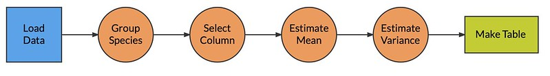

## The Data

For these questions, we will be using the data set from the [Rice Rivers Center](https://ricerivers.vcu.edu) and is loaded in as raw data from the code below.

```r
library( readr )
library( tidyverse )
library( lubridate )


url <- "https://docs.google.com/spreadsheets/d/1Mk1YGH9LqjF7drJE-td1G_JkdADOU0eMlrP01WFBT8s/pub?gid=0&single=true&output=csv"
rice <- read_csv( url )

summary( rice )
```

```
   DateTime            RecordID          PAR           WindSpeed_mph       WindDir
 Length:8199        Min.   :43816   Min.   :   0.000   Min.   : 0.000   Min.   :  0.00
 Class :character   1st Qu.:45866   1st Qu.:   0.000   1st Qu.: 2.467   1st Qu.: 37.31
 Mode  :character   Median :47915   Median :   0.046   Median : 4.090   Median :137.30
                    Mean   :47915   Mean   : 241.984   Mean   : 5.446   Mean   :146.20
                    3rd Qu.:49964   3rd Qu.: 337.900   3rd Qu.: 7.292   3rd Qu.:249.95
                    Max.   :52014   Max.   :1957.000   Max.   :30.650   Max.   :360.00

    AirTempF       RelHumidity        BP_HG          Rain_in            H2O_TempC
 Min.   : 3.749   Min.   :15.37   Min.   :29.11   Min.   :0.0000000   Min.   :-0.140
 1st Qu.:31.545   1st Qu.:42.25   1st Qu.:29.87   1st Qu.:0.0000000   1st Qu.: 3.930
 Median :37.440   Median :56.40   Median :30.01   Median :0.0000000   Median : 5.450
 Mean   :38.795   Mean   :58.37   Mean   :30.02   Mean   :0.0008412   Mean   : 5.529
 3rd Qu.:46.410   3rd Qu.:76.59   3rd Qu.:30.21   3rd Qu.:0.0000000   3rd Qu.: 7.410
 Max.   :74.870   Max.   :93.00   Max.   :30.58   Max.   :0.3470000   Max.   :13.300
                                                                      NA's   :1
  SpCond_mScm      Salinity_ppt          PH           PH_mv        Turbidity_ntu
 Min.   :0.0110   Min.   :0.0000   Min.   :6.43   Min.   :-113.8   Min.   :  6.20
 1st Qu.:0.1430   1st Qu.:0.0700   1st Qu.:7.50   1st Qu.: -47.8   1st Qu.: 15.50
 Median :0.1650   Median :0.0800   Median :7.58   Median : -43.8   Median : 21.80
 Mean   :0.1611   Mean   :0.0759   Mean   :7.60   Mean   : -44.5   Mean   : 24.54
 3rd Qu.:0.1760   3rd Qu.:0.0800   3rd Qu.:7.69   3rd Qu.: -38.9   3rd Qu.: 30.30
 Max.   :0.2110   Max.   :0.1000   Max.   :9.00   Max.   :  28.5   Max.   :187.70
 NA's   :1        NA's   :1        NA's   :1      NA's   :1        NA's   :1
    Chla_ugl       BGAPC_CML        BGAPC_rfu         ODO_sat         ODO_mgl
 Min.   :  1.3   Min.   :   188   Min.   :  0.10   Min.   : 87.5   Min.   :10.34
 1st Qu.:  3.7   1st Qu.:   971   1st Qu.:  0.50   1st Qu.: 99.2   1st Qu.:12.34
 Median :  6.7   Median :  1369   Median :  0.70   Median :101.8   Median :12.88
 Mean   :137.3   Mean   :153571   Mean   : 72.91   Mean   :102.0   Mean   :12.88
 3rd Qu.:302.6   3rd Qu.:345211   3rd Qu.:163.60   3rd Qu.:104.1   3rd Qu.:13.34
 Max.   :330.1   Max.   :345471   Max.   :163.70   Max.   :120.8   Max.   :14.99
 NA's   :1       NA's   :1        NA's   :1        NA's   :1       NA's   :1
    Depth_ft        Depth_m      SurfaceWaterElev_m_levelNad83m
 Min.   :12.15   Min.   :3.705   Min.   :-32.53
 1st Qu.:14.60   1st Qu.:4.451   1st Qu.:-31.78
 Median :15.37   Median :4.684   Median :-31.55
 Mean   :15.34   Mean   :4.677   Mean   :-31.55
 3rd Qu.:16.12   3rd Qu.:4.913   3rd Qu.:-31.32
 Max.   :17.89   Max.   :5.454   Max.   :-30.78
```

## The Questions

Provide your answers as text (e.g., using complete sentences, etc.) and include visual output in tabular or graphical form to support your assertions. The *key point here* is that **you** need to develop an *evidence-based* narrative to address these questions.

In all of the following questions, use the operative verbs as well as the pipe operator `%>%` to extract from the data the required output.

1. On average, is there more rain on Mondays, at daytime, or at night?
2. What is the overall relationship between salinity and pH? Does this pattern hold when considering each month individually?
3. Turbidity is a measurement of the opaqueness of water. In the rice data, we have a measure of Chlorophyll A in the water. For estimates where there is more than 200 $µg*l^{-1}$, describe the relationship between these two variables.
4. Show the pattern of tides during the work week that includes Valentines Day in 2004.
5. Summarize estimates of Wind direction for February. Pay close attention to what this variable is actually measuring and how you want to display its underlying patterns.